# tidy-model

Aleph Girmaye

2025-02-17

## Introduction

This R Markdown document demonstrates my abilities to use models for data analysis using a data set collected on crickets.

## What is that sound?

In this report, we examine what factors predict a cricket’s chirp rate.

```
##              species        temp            rate
##  O. exclamationis:14   Min.   :17.20   Min.   : 44.30
##  O. niveus       :17   1st Qu.:20.80   1st Qu.: 59.45
##                        Median :24.00   Median : 76.20
##                        Mean   :23.76   Mean   : 72.89
##                        3rd Qu.:26.35   3rd Qu.: 85.25
##                        Max.   :30.40   Max.   :101.70
```

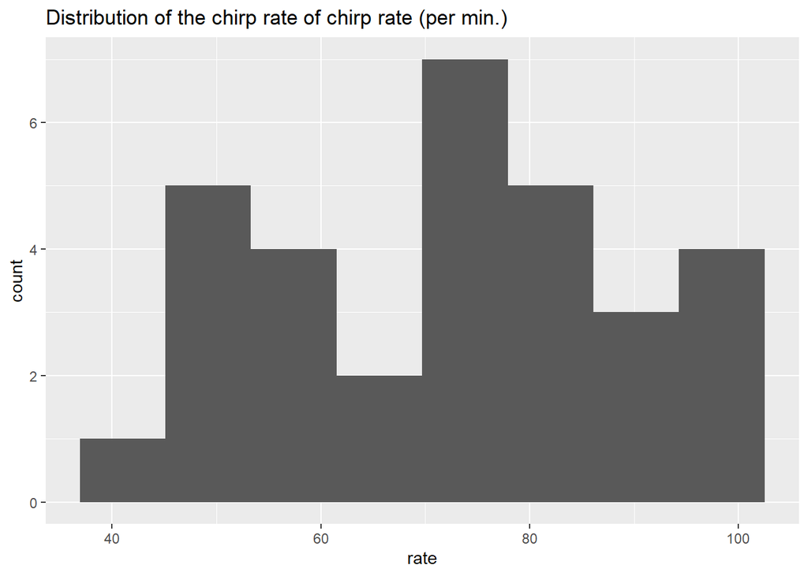

## Temperature affects chirp rate.

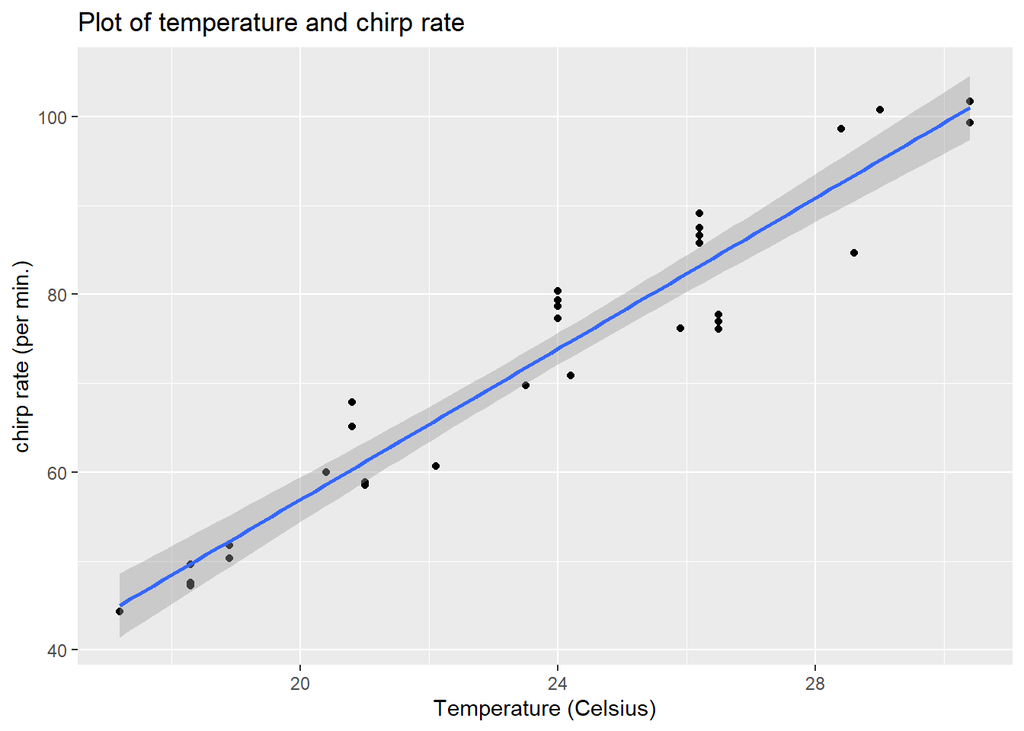

```
##
## Call:
## lm(formula = rate ~ temp, data = crickets)
##
## Residuals:
##     Min      1Q  Median      3Q     Max
## -8.7044 -2.5789 -0.4466  4.5353  7.5916
##
## Coefficients:
##             Estimate Std. Error t value Pr(>|t|)
## (Intercept) -27.9476     5.5937  -4.996 2.56e-05 ***
## temp          4.2431     0.2325  18.251  < 2e-16 ***
## ---
## Signif. codes:  0 '***' 0.001 '**' 0.01 '*' 0.05 '.' 0.1 ' ' 1
##
## Residual standard error: 4.868 on 29 degrees of freedom
## Multiple R-squared:  0.9199, Adjusted R-squared:  0.9171
## F-statistic: 333.1 on 1 and 29 DF,  p-value: < 2.2e-16
```

Based on a scatter plot of temperature and chirping and a correlation test, it seems that as temperature increases one degree, the rate of chirping increases about 4.2 chirps per minute.

## Species-specific effects of temperature on chirping

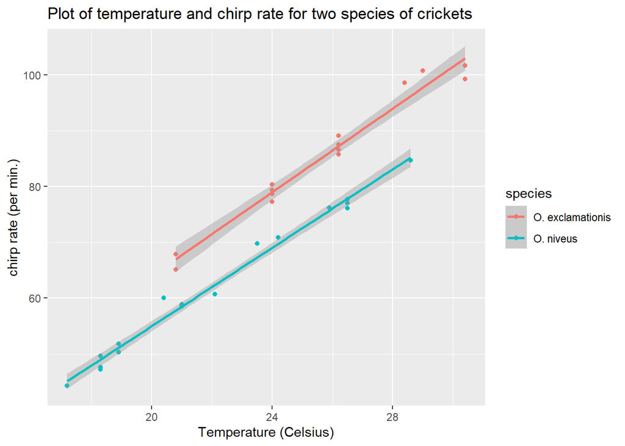

```
##
## Call:
## lm(formula = rate ~ temp + species, data = crickets)
##
## Residuals:
##     Min      1Q  Median      3Q     Max
## -3.0128 -1.1296 -0.3912  0.9650  3.7800
##
## Coefficients:
##                   Estimate Std. Error t value Pr(>|t|)
## (Intercept)       -7.21091    2.55094  -2.827  0.00858 **
## temp               3.60275    0.09729  37.032  < 2e-16 ***
## speciesO. niveus -10.06529    0.73526 -13.689 6.27e-14 ***
## ---
## Signif. codes:  0 '***' 0.001 '**' 0.01 '*' 0.05 '.' 0.1 ' ' 1
##
## Residual standard error: 1.786 on 28 degrees of freedom
## Multiple R-squared:  0.9896, Adjusted R-squared:  0.9888
## F-statistic:  1331 on 2 and 28 DF,  p-value: < 2.2e-16
```

Compared to the first visual, this scatter plot and summary model shows a better correlation between chirp rates and temperature by splitting the data points by species. This shows us that “exclamationis” has a consistently higher chirp rate than “niveus” at the same temperature. Also based this model we get a better account of the data with a 99 % of the variance.

## Interactions

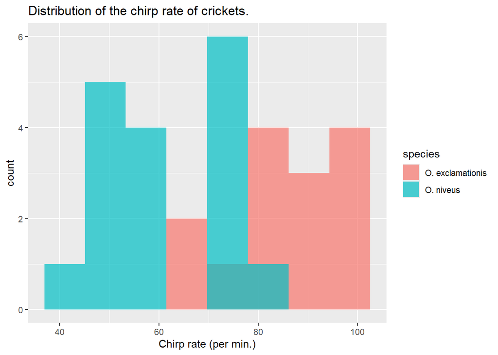

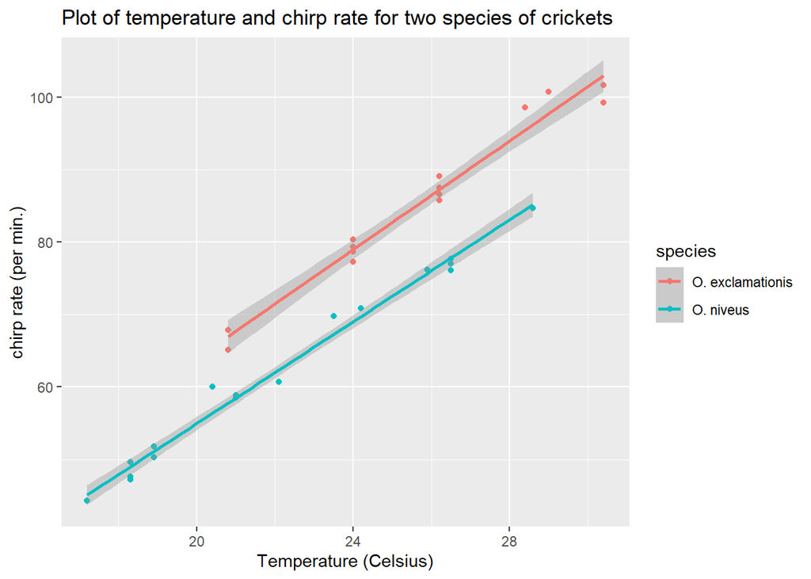

```
##
## Call:
## lm(formula = rate ~ temp + species + temp:species, data = crickets)
##
## Residuals:
##     Min      1Q  Median      3Q     Max
## -3.7031 -1.3417 -0.1235  0.8100  3.6330
##
## Coefficients:
##                       Estimate Std. Error t value Pr(>|t|)
## (Intercept)           -11.0408     4.1515  -2.659    0.013 *
## temp                    3.7514     0.1601  23.429   <2e-16 ***
## speciesO. niveus       -4.3484     4.9617  -0.876    0.389
## temp:speciesO. niveus  -0.2340     0.2009  -1.165    0.254
## ---
## Signif. codes:  0 '***' 0.001 '**' 0.01 '*' 0.05 '.' 0.1 ' ' 1
##
## Residual standard error: 1.775 on 27 degrees of freedom
## Multiple R-squared:  0.9901, Adjusted R-squared:  0.989
## F-statistic: 898.9 on 3 and 27 DF,  p-value: < 2.2e-16
```

```
## Analysis of Variance Table
##
## Model 1: rate ~ temp + species
## Model 2: rate ~ temp + species + temp:species
##   Res.Df    RSS Df Sum of Sq     F Pr(>F)
## 1     28 89.350
## 2     27 85.074  1    4.2758 1.357 0.2542
```

After checking the intersection between temperature and species by adding a temperature-species interaction we see that the relationship between temperature and chirp rate does not differ meaningfully between species. Because of this it s better to stick with the species model.